# Categorical Variables

TEMBA Statistics 2026

## The data: LendingClub loans

- The `lending` data records 92,902 peer-to-peer loans issued between 2008 and 2012, each with a final outcome.
- `purpose` records why the borrower took the loan (14 categories).
- `default` records whether the loan was `Charged Off` — the borrower stopped paying and the balance was written off — or `Fully Paid`.

## Kinds of categorical variables

- A **categorical variable** records which of several groups an observation belongs to.
- A **nominal** variable’s categories have no natural order: loan `purpose`.
- An **ordinal** variable’s categories fall in a natural order, but the spacing between them is not measurable: loan `grade`, from `A` down to `G`.
- A **binary** variable has exactly two categories, so it can be nominal or ordinal: did the loan default?

## Frequency tables

A **frequency table** counts how many observations fall in each category; dividing by the total gives the **proportion**.

| Purpose | Count | Proportion |
| --- | --- | --- |
| debt_consolidation | 49409 | 0.532 (53.2%) |
| credit_card | 15459 | 0.166 (16.6%) |
| other | 7012 | 0.075 (7.5%) |
| home_improvement | 5856 | 0.063 (6.3%) |
| major_purchase | 3543 | 0.038 (3.8%) |
| small_business | 3191 | 0.034 (3.4%) |
| car | 2449 | 0.026 (2.6%) |
| wedding | 1676 | 0.018 (1.8%) |
| medical | 1323 | 0.014 (1.4%) |
| moving | 976 | 0.011 (1.1%) |
| house | 799 | 0.009 (0.9%) |
| vacation | 722 | 0.008 (0.8%) |
| educational | 313 | 0.003 (0.3%) |
| renewable_energy | 174 | 0.002 (0.2%) |

## Bar charts, dot plots, and pie charts

- A **bar chart** or **dot plot** shows each category’s count or proportion as a length or position on a common axis. Differences of a percentage point or two stay visible.
- A **pie chart** shows the same numbers as angles and areas. Two slices a few percentage points apart look the same, and ranking several mid-sized slices is harder still.
- With more than a handful of categories, or when comparing them is the point, use bars or dots.

## The distribution of loan purpose

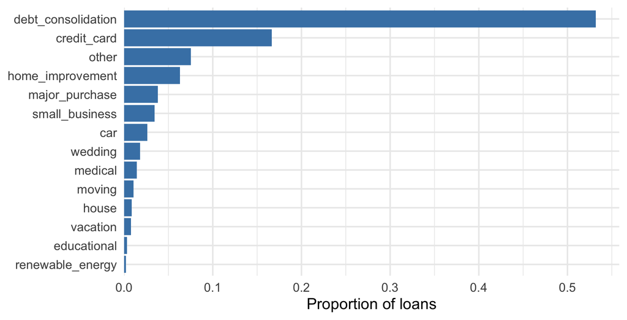

## The same distribution as a dot plot

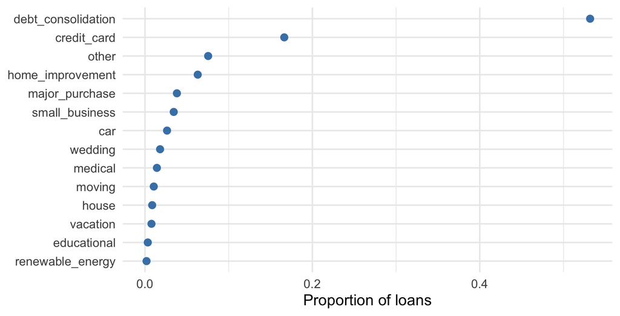

## Rating national economic conditions

Each fall the Federal Reserve’s [Survey of Household Economics and Decisionmaking](https://www.federalreserve.gov/consumerscommunities/shed.htm) asks a national sample of U.S. adults to rate economic conditions in the country today. The 2025 wave surveyed 12,934 people.

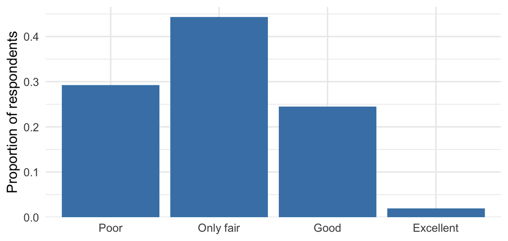

## Ordinal categories keep their order

- We sorted `purpose` by size because its labels have no order. An ordinal variable’s bars stay in their natural order: here, worst to best, left to right.
- The tallest bar, “only fair,” sits second from the left; the order tells you where that answer falls on the scale.
- Only 1.9% answered “excellent.” Kept at the end of the scale, that bar shows the top of the scale is nearly empty; sorted by height, it would just be the rarest answer.

## Dummy (indicator) variables

A **dummy variable** (or **indicator variable**) equals 1 when an observation belongs to a category and 0 when it does not:

$$\text{default}_i =
\begin{cases}
1 & \text{if loan } i \text{ was charged off} \\
0 & \text{if loan } i \text{ was fully paid.}
\end{cases}$$

| Purpose | Loan status | default |
| --- | --- | --- |
| credit_card | Fully Paid | 0 |
| small_business | Fully Paid | 0 |
| other | Fully Paid | 0 |
| car | Charged Off | 1 |
| other | Fully Paid | 0 |

That single column carries everything the two labels told us, in a form we can add up and average.

## A proportion is the mean of a 0/1 variable

- The mean of the `default` dummy is 0.154, and 15.4% of these loans were charged off.
- Take the mean of a 0/1 column and you get back the proportion of 1s. Summing the column counts the 1s, so dividing by $n$ gives their share:

$$\hat{p} = \frac{1}{n}\sum_{i=1}^{n} x_i = \frac{\text{number of 1s}}{n} = \text{proportion of 1s}$$

We write a sample proportion as $\hat{p}$, read aloud as “p-hat.” It is a sample mean in disguise.

## The spread of a 0/1 variable

Predict a random loan’s outcome, knowing only the 15.4% default rate.

- Your best guess is “no default,” and you will be right about 84.6% of the time. That is a fairly predictable outcome.
- A rarer outcome is easier still: if one loan in a hundred defaulted, guessing “no default” every time would be right 99% of the time.
- Where does prediction get hard? At a coin flip: if half of loans defaulted, no guessing rule would beat 50-50.
- So the spread of a 0/1 variable should be smallest near 0 or 1 and largest in the middle.

## Variance of a 0/1 variable

The variance of a 0/1 variable depends on $\hat{p}$ alone:

$$s^2 \approx \hat{p}\,(1 - \hat{p}),$$

the chance a randomly selected observation is a 1 times the chance it is a 0.

- Largest at $\hat{p} = 0.5$: a coin flip.
- Shrinks toward zero as $\hat{p}$ approaches 0 or 1: the outcome is nearly certain.

## Variance as a function of $\hat{p}$

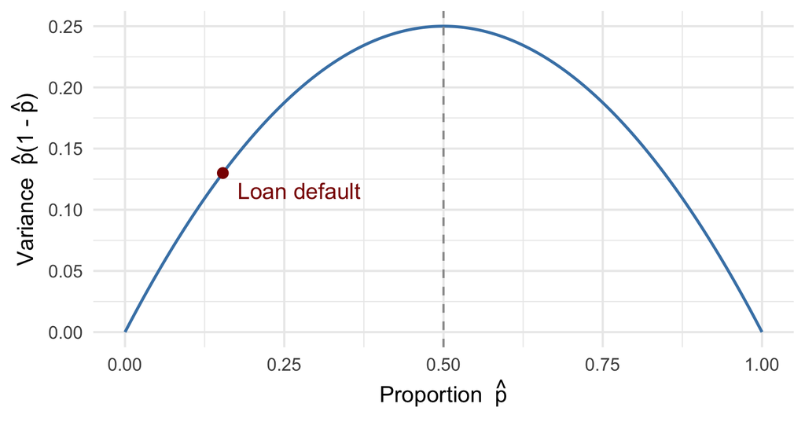

At $\hat{p}$ = 0.154 the variance is 0.130, well below its maximum of 0.25: defaults are fairly predictable. The standard deviation is 0.361.